# 8 Guild

```r
library(grassland)
theme_set(ggthemes::theme_few())
```

In the main analysis, we characterized community composition in the climate space. Previous studies often use species guilds, such as examining changes in grass and forb dominance, and have yielded inconsistent observations and experimental results. For comparison, we examined community compositional shifts characterized by species guilds. We used three common classifications for species guilds: their origin (native vs. non-native), life history (annual vs. perennial), or functional groups (grass vs. forb).

## Compare species niches by guild

We first compared the climate niches of species of different guilds using permutational multivariate analysis of variance (PERMANOVA).

```r
dat_guild_niche <- calc_guild_niche(dat_community, dat_niche)
```

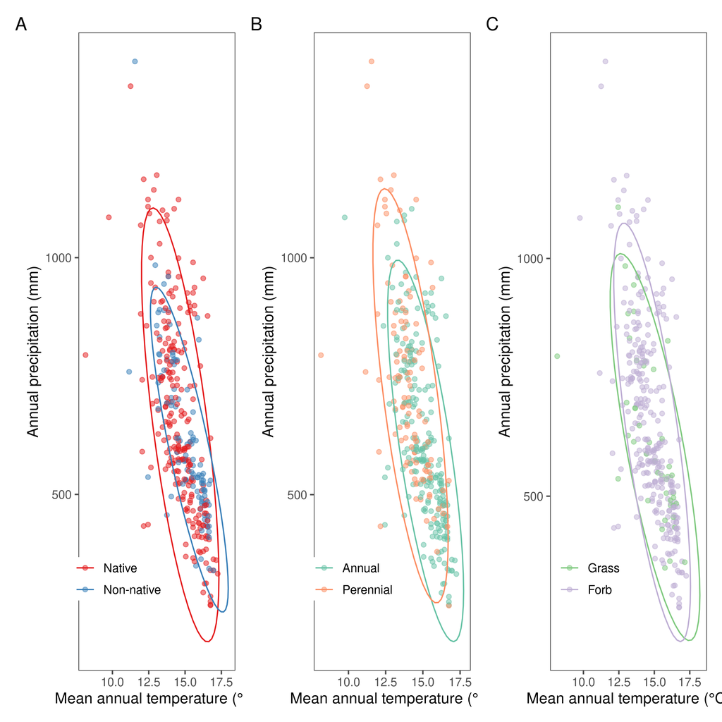

```r
gg_guild_niche <- plot_guild_niche(dat_guild_niche = dat_guild_niche)
gg_guild_niche
```

```r
res_guild_niche <- test_guild_niche(dat_guild_niche = dat_guild_niche)
res_guild_niche
```

```
#> $Origin
#> Permutation test for adonis under reduced model
#> Terms added sequentially (first to last)
#> Permutation: free
#> Number of permutations: 999
#>
#> vegan::adonis2(formula = response ~ guild, data = predict)
#>           Df SumOfSqs      R2      F Pr(>F)
#> guild      1   0.0676 0.00899 3.1567  0.069 .
#> Residual 348   7.4567 0.99101
#> Total    349   7.5243 1.00000
#> ---
#> Signif. codes:  0 '***' 0.001 '**' 0.01 '*' 0.05 '.' 0.1 ' ' 1
#>
#> $`Life history`
#> Permutation test for adonis under reduced model
#> Terms added sequentially (first to last)
#> Permutation: free
#> Number of permutations: 999
#>
#> vegan::adonis2(formula = response ~ guild, data = predict)
#>           Df SumOfSqs      R2      F Pr(>F)
#> guild      1   0.4959 0.06616 24.583  0.001 ***
#> Residual 347   6.9994 0.93384
#> Total    348   7.4953 1.00000
#> ---
#> Signif. codes:  0 '***' 0.001 '**' 0.01 '*' 0.05 '.' 0.1 ' ' 1
#>
#> $`Functional group`
#> Permutation test for adonis under reduced model
#> Terms added sequentially (first to last)
#> Permutation: free
#> Number of permutations: 999
#>
#> vegan::adonis2(formula = response ~ guild, data = predict)
#>           Df SumOfSqs      R2     F Pr(>F)
#> guild      1   0.0108 0.00149 0.488  0.487
#> Residual 328   7.2851 0.99851
#> Total    329   7.2959 1.00000
```

## Analyze community shift with guild

Similar to the analysis of changes in CTI and CPI, we then examined the relative abundance of species of specific guilds at the 12 observational sites and the JRGCE warming experiment, by fitting linear regressions with the percentages of natives, annuals, and grasses as response variables and year as the predictor.

Plot guild percentage change over time from observational and experimental data.

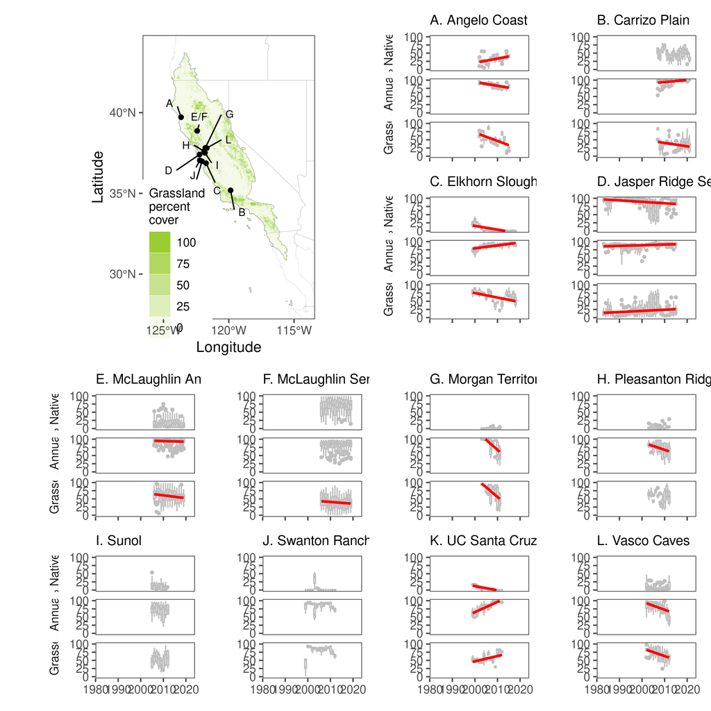

```r
gg_guild_percentage_obs <- plot_guild_percentage(option = "obs", dat_community = dat_community)
gg_guild_percentage_obs
```

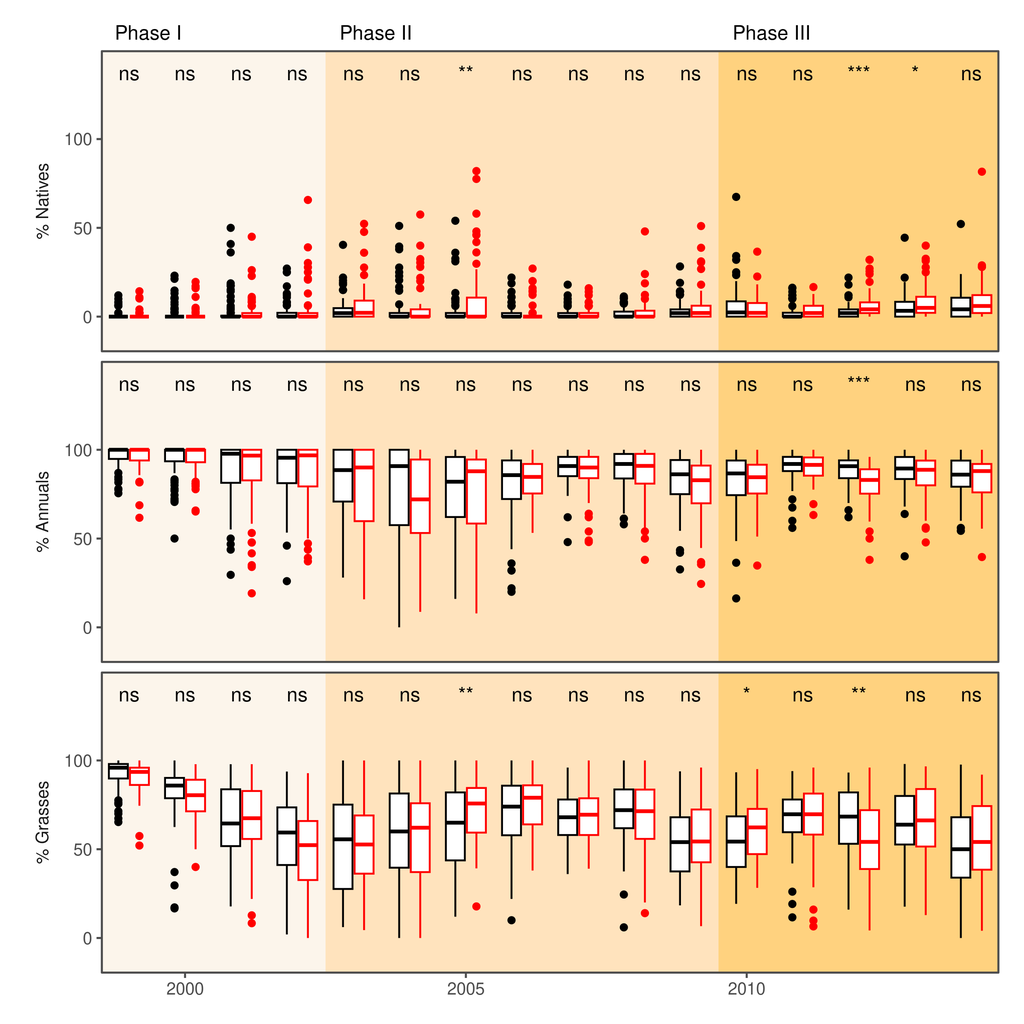

```r
gg_guild_percentage_exp <- plot_guild_percentage(option = "exp", dat_community = dat_community)
gg_guild_percentage_exp
```

Grassland communities had inconsistent compositional changes in species origin (measured by the percentage of natives), life history (measured by the percentage of annuals), and functional group (measured by the percentage of grasses) in 12 long-term observational sites across the California Floristic Province and in the Jasper Ridge Global Change Experiment.

Output figures and R data files.

```r
save_figure(out = list(
  guild_niche = gg_guild_niche,
  guild_perc_obs = gg_guild_percentage_obs,
  guild_perc_exp = gg_guild_percentage_exp
))
```